# Practical Machine Learning Project

## Acknowledgment

The data set comes from **Groupware@LES**, at http://groupware.les.inf.puc-rio.br/har. Analyses are also informed by the following paper:  
Velloso, E.; Bulling, A.; Gellersen, H.; Ugulino, W.; Fuks, H. Qualitative Activity Recognition of Weight Lifting Exercises. *Proceedings of 4th International Conference in Cooperation with SIGCHI (Augmented Human ’13).* Stuttgart, Germany: ACM SIGCHI, 2013.

## Load and prepare the training and testing datasets

In this project, “unusable variables” are defined as those that (1) are near zero covariates (with little varibility), and (2) have missing values for more than 80% of observations.

```r
# load datasets
download.file("https://d396qusza40orc.cloudfront.net/predmachlearn/pml-training.csv", destfile="pml-training.csv", method= "wget")
download.file("https://d396qusza40orc.cloudfront.net/predmachlearn/pml-testing.csv", destfile="pml-test.csv", method= "wget")
train <- read.csv("pml-training.csv", row.names = 1)
test <- read.csv("pml-test.csv", row.names = 1)
# identify and remove unusable variables (near zero covariates)
library("caret")
nsv <- nearZeroVar(train, saveMetrics = T)
train <- train[,!nsv$nzv]
test <- test[,!nsv$nzv]
# identify and remove unusable variables (>80% missing values)
missingV <- as.logical(rep(TRUE, ncol(train)))
for (i in 1:ncol(train)) {
        n <-0
        for (j in 1:nrow(train)) {
                if (is.na(train[j,i]) | train[j,i]=="") n <- n+1
        }
        if (n > 0.8 * nrow(train)) missingV[i] <- FALSE
}
train <- train[,missingV]; train <- train[,-c(1:5)]
test <- test[,missingV]; test <- test[,-c(1:5)]
```

Potential predictors shall come from the following:

```r
names(train)
```

```
##  [1] "roll_belt"            "pitch_belt"           "yaw_belt"
##  [4] "total_accel_belt"     "gyros_belt_x"         "gyros_belt_y"
##  [7] "gyros_belt_z"         "accel_belt_x"         "accel_belt_y"
## [10] "accel_belt_z"         "magnet_belt_x"        "magnet_belt_y"
## [13] "magnet_belt_z"        "roll_arm"             "pitch_arm"
## [16] "yaw_arm"              "total_accel_arm"      "gyros_arm_x"
## [19] "gyros_arm_y"          "gyros_arm_z"          "accel_arm_x"
## [22] "accel_arm_y"          "accel_arm_z"          "magnet_arm_x"
## [25] "magnet_arm_y"         "magnet_arm_z"         "roll_dumbbell"
## [28] "pitch_dumbbell"       "yaw_dumbbell"         "total_accel_dumbbell"
## [31] "gyros_dumbbell_x"     "gyros_dumbbell_y"     "gyros_dumbbell_z"
## [34] "accel_dumbbell_x"     "accel_dumbbell_y"     "accel_dumbbell_z"
## [37] "magnet_dumbbell_x"    "magnet_dumbbell_y"    "magnet_dumbbell_z"
## [40] "roll_forearm"         "pitch_forearm"        "yaw_forearm"
## [43] "total_accel_forearm"  "gyros_forearm_x"      "gyros_forearm_y"
## [46] "gyros_forearm_z"      "accel_forearm_x"      "accel_forearm_y"
## [49] "accel_forearm_z"      "magnet_forearm_x"     "magnet_forearm_y"
## [52] "magnet_forearm_z"     "classe"
```

## Train models using Random Forests.

As this data is clearly non-linear, linear model prodictions such as regression cannot be used. It tends to overfit, so cross-validation is very important to increase accuracy. In particular, K-fold cross-validation technique is used. K is set to be 5, for a relatively smaller out-of-sample error rate. Three different models will be fitted to the training dataset:

1. Classification Tree, for its better performance in nonlinear settings.
2. Random Forests, as one of the top performing algorithms in predicting contests.
3. Linear Discriminary Analsysis, which assumes data to follow a probabilistic model and uses Bayes’ theorem to identify optimal classifiers.

```r
# Split the dataset into a 70% training and 30% testing datasets
set.seed(12345)
inTrain <- createDataPartition(y=train$classe, p=0.7, list=FALSE)
fortraining <- train[inTrain, ]
fortesting <- train[-inTrain, ]
# Use k-fold cross-validation and set k to be 5
k_fold5 <- trainControl(method="cv", number=5)
# Apply Random Forests
library(randomForest)
library(rpart)
set.seed(12345)
modFit1 <- train(classe ~ ., method="rpart", trControl = k_fold5, data=fortraining)
set.seed(12345)
modFit2 <- train(classe ~ ., method="rf", trControl = k_fold5, data=fortraining)
set.seed(12345)
modFit3<- train(classe ~ ., method="lda", trControl = k_fold5, data=fortraining)
```

## Evaluate Model Fits

**1. Classification Tree** model give a poor fit, as first of all, actual class D is scattered in what is predicted as A, B, and C. The accuracy rate of the model is only about 49.63%.

```r
library(rattle); library(rpart)
```

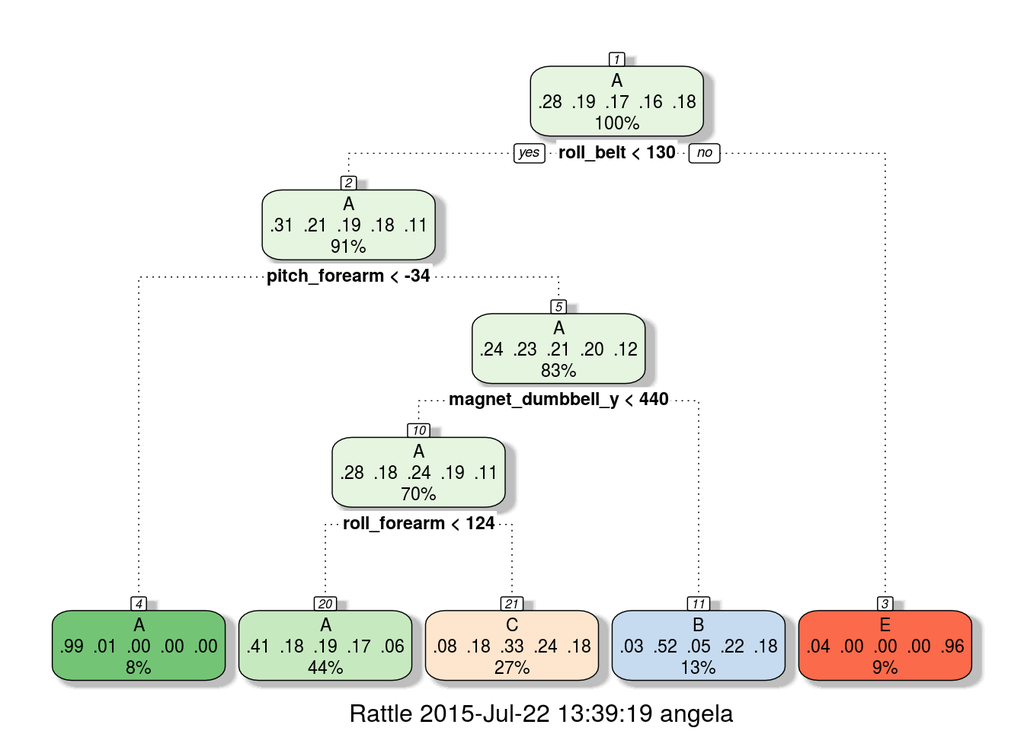

```r
fancyRpartPlot(modFit1$finalModel)
```

```r
ClassificationT <- predict(modFit1, newdata = fortesting[,-53])
confusionMatrix(fortesting$classe, ClassificationT)
```

```
## Confusion Matrix and Statistics
##
##           Reference
## Prediction    A    B    C    D    E
##          A 1494   21  128    0   31
##          B  470  380  289    0    0
##          C  467   29  530    0    0
##          D  438  184  342    0    0
##          E  141  147  277    0  517
##
## Overall Statistics
##
##                Accuracy : 0.4963
##                  95% CI : (0.4835, 0.5092)
##     No Information Rate : 0.5115
##     P-Value [Acc > NIR] : 0.9902
##
##                   Kappa : 0.3425
##  Mcnemar's Test P-Value : NA
##
## Statistics by Class:
##
##                      Class: A Class: B Class: C Class: D Class: E
## Sensitivity            0.4963  0.49934  0.33844       NA  0.94343
## Specificity            0.9374  0.85187  0.88516   0.8362  0.89414
## Pos Pred Value         0.8925  0.33363  0.51657       NA  0.47782
## Neg Pred Value         0.6400  0.91972  0.78679       NA  0.99355
## Prevalence             0.5115  0.12931  0.26610   0.0000  0.09312
## Detection Rate         0.2539  0.06457  0.09006   0.0000  0.08785
## Detection Prevalence   0.2845  0.19354  0.17434   0.1638  0.18386
## Balanced Accuracy      0.7169  0.67561  0.61180       NA  0.91878
```

**2. Random Forests** performs at best when 2 variables are randomly sampled determine each split (with the highest accuracy of 99.14%), which will be chosen. Accuracy SD is not high, which means these classes are easily separable. The confusion matrix shows the overall accuracy of this model to be an outstanding 98.9%. If this model is used, the out-of-sample error would be 1.1%.

```r
modFit2
```

```
## Random Forest
##
## 13737 samples
##    52 predictors
##     5 classes: 'A', 'B', 'C', 'D', 'E'
##
## No pre-processing
## Resampling: Cross-Validated (5 fold)
##
## Summary of sample sizes: 10989, 10989, 10989, 10990, 10991
##
## Resampling results across tuning parameters:
##
##   mtry  Accuracy   Kappa      Accuracy SD  Kappa SD
##    2    0.9914101  0.9891331  0.001718597  0.002174670
##   27    0.9895172  0.9867394  0.002145057  0.002712719
##   52    0.9825283  0.9778979  0.006232956  0.007883037
##
## Accuracy was used to select the optimal model using  the largest value.
## The final value used for the model was mtry = 2.
```

```r
RandomF <- predict(modFit2, newdata=fortesting[,-53])
confusionMatrix(fortesting$classe, RandomF)
```

```
## Confusion Matrix and Statistics
##
##           Reference
## Prediction    A    B    C    D    E
##          A 1673    1    0    0    0
##          B   14 1120    5    0    0
##          C    0   16 1006    4    0
##          D    0    0   22  942    0
##          E    0    0    0    3 1079
##
## Overall Statistics
##
##                Accuracy : 0.989
##                  95% CI : (0.9859, 0.9915)
##     No Information Rate : 0.2867
##     P-Value [Acc > NIR] : < 2.2e-16
##
##                   Kappa : 0.986
##  Mcnemar's Test P-Value : NA
##
## Statistics by Class:
##
##                      Class: A Class: B Class: C Class: D Class: E
## Sensitivity            0.9917   0.9850   0.9739   0.9926   1.0000
## Specificity            0.9998   0.9960   0.9959   0.9955   0.9994
## Pos Pred Value         0.9994   0.9833   0.9805   0.9772   0.9972
## Neg Pred Value         0.9967   0.9964   0.9944   0.9986   1.0000
## Prevalence             0.2867   0.1932   0.1755   0.1613   0.1833
## Detection Rate         0.2843   0.1903   0.1709   0.1601   0.1833
## Detection Prevalence   0.2845   0.1935   0.1743   0.1638   0.1839
## Balanced Accuracy      0.9957   0.9905   0.9849   0.9941   0.9997
```

**3. Lineary Discriminant Analysis** performs better than Classification Tree on this data, but is not as good as Random Forests. Its overall accuracy is 69.62%.

```r
modFit3
```

```
## Linear Discriminant Analysis
##
## 13737 samples
##    52 predictors
##     5 classes: 'A', 'B', 'C', 'D', 'E'
##
## No pre-processing
## Resampling: Cross-Validated (5 fold)
##
## Summary of sample sizes: 10989, 10989, 10989, 10990, 10991
##
## Resampling results
##
##   Accuracy   Kappa      Accuracy SD  Kappa SD
##   0.7051758  0.6267868  0.004580274  0.005810575
##
##
```

```r
LinearDA <- predict(modFit3, newdata=fortesting[,-53])
confusionMatrix(fortesting$classe, LinearDA)
```

```
## Confusion Matrix and Statistics
##
##           Reference
## Prediction    A    B    C    D    E
##          A 1380   36  133  116    9
##          B  191  709  142   43   54
##          C   91  104  658  144   29
##          D   48   49  125  698   44
##          E   38  193   99  100  652
##
## Overall Statistics
##
##                Accuracy : 0.6962
##                  95% CI : (0.6842, 0.7079)
##     No Information Rate : 0.297
##     P-Value [Acc > NIR] : < 2.2e-16
##
##                   Kappa : 0.6155
##  Mcnemar's Test P-Value : < 2.2e-16
##
## Statistics by Class:
##
##                      Class: A Class: B Class: C Class: D Class: E
## Sensitivity            0.7895   0.6499   0.5687   0.6340   0.8274
## Specificity            0.9289   0.9103   0.9222   0.9444   0.9156
## Pos Pred Value         0.8244   0.6225   0.6413   0.7241   0.6026
## Neg Pred Value         0.9126   0.9195   0.8973   0.9181   0.9717
## Prevalence             0.2970   0.1854   0.1966   0.1871   0.1339
## Detection Rate         0.2345   0.1205   0.1118   0.1186   0.1108
## Detection Prevalence   0.2845   0.1935   0.1743   0.1638   0.1839
## Balanced Accuracy      0.8592   0.7801   0.7454   0.7892   0.8715
```

## Select Best Model for Final Prediction: Random Forests

Our Random Forests model’s overall accuracy is 98.9% with 5 folds cross validation, which means that after aplitting the sample in a stratified manner 5 times for model training, this model prediction expects an out-of-sample error rate of 1.1%.

Apply the above Random Forests model to fit the original testing dataset. The predictions are:

```r
set.seed(12345)
predict(modFit2, newdata=test)
```

```
##  [1] B A B A A E D B A A B C B A E E A B B B
## Levels: A B C D E
```